# Manejo de Datos Faltantes y Atípicos en R

Clase de R

## Objetivos de la clase

- Identificar valores faltantes en un conjunto de datos.
- Contar, visualizar y tratar los datos faltantes.
- Aplicar estrategias como eliminación, imputación y análisis exploratorio.

## 1. Detección de datos faltantes

```r
# Crear un conjunto de datos con valores faltantes
datos <- data.frame(
  nombre = c("Ana", "Luis", "Carlos", "Beatriz", NA),
  edad = c(25, NA, 32, 28, 22),
  puntaje = c(85, 90, NA, 88, 75)
)

# Ver el conjunto de datos
print(datos)
```

```
##    nombre edad puntaje
## 1     Ana   25      85
## 2    Luis   NA      90
## 3  Carlos   32      NA
## 4 Beatriz   28      88
## 5    <NA>   22      75
```

```r
# Identificar valores NA
is.na(datos)
```

```
##      nombre  edad puntaje
## [1,]  FALSE FALSE   FALSE
## [2,]  FALSE  TRUE   FALSE
## [3,]  FALSE FALSE    TRUE
## [4,]  FALSE FALSE   FALSE
## [5,]   TRUE FALSE   FALSE
```

```r
# Contar datos faltantes por columna
colSums(is.na(datos))
```

```
##  nombre    edad puntaje
##       1       1       1
```

## 2. Eliminar observaciones con NA

```r
# Eliminar filas con valores faltantes
na.omit(datos)
```

```
##    nombre edad puntaje
## 1     Ana   25      85
## 4 Beatriz   28      88
```

```r
# Usar dplyr para filtrar filas completas
library(dplyr)
datos %>% filter(complete.cases(.))
```

```
##    nombre edad puntaje
## 1     Ana   25      85
## 2 Beatriz   28      88
```

## 3. Visualización de datos faltantes

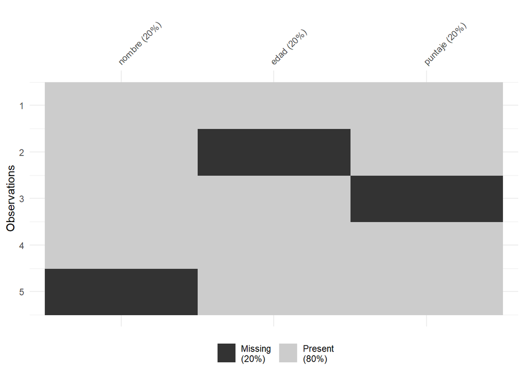

```r
# Visualizar patrón de valores faltantes
vis_miss(datos)
```

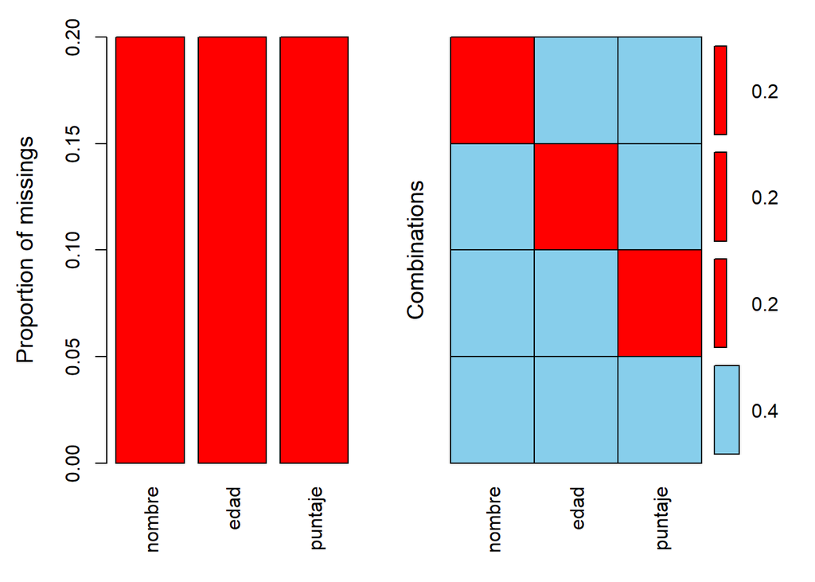

```
##
##  Variables sorted by number of missings:
##  Variable Count
##    nombre   0.2
##      edad   0.2
##   puntaje   0.2
```

```r
# Gráfico de agregación de faltantes
aggr(datos, col = c('skyblue', 'red'), numbers = TRUE, sortVars = TRUE)
```

## 4. Imputación de datos faltantes

### Imputación simple (media)

```r
# Imputar edad con la media
datos$edad[is.na(datos$edad)] <- mean(datos$edad, na.rm = TRUE)
print(datos)
```

```
##    nombre  edad puntaje
## 1     Ana 25.00      85
## 2    Luis 26.75      90
## 3  Carlos 32.00      NA
## 4 Beatriz 28.00      88
## 5    <NA> 22.00      75
```

### Imputación múltiple con `mice`

```r
# Generar imputaciones
imp <- mice(datos, m = 5, method = "pmm", seed = 123)
# Conjunto imputado (primera versión)
datos_imputados <- complete(imp, 1)
print(datos_imputados)
```

```
##    nombre  edad puntaje
## 1     Ana 25.00      85
## 2    Luis 26.75      90
## 3  Carlos 32.00      90
## 4 Beatriz 28.00      88
## 5    <NA> 22.00      75
```

## 5. Actividad práctica

Utilizar el dataset `airquality` incluido en R.

```r
data("airquality")

# Explorar el conjunto de datos
head(airquality)
```

```
##   Ozone Solar.R Wind Temp Month Day
## 1    41     190  7.4   67     5   1
## 2    36     118  8.0   72     5   2
## 3    12     149 12.6   74     5   3
## 4    18     313 11.5   62     5   4
## 5    NA      NA 14.3   56     5   5
## 6    28      NA 14.9   66     5   6
```

```r
summary(airquality)
```

```
##      Ozone           Solar.R           Wind             Temp
##  Min.   :  1.00   Min.   :  7.0   Min.   : 1.700   Min.   :56.00
##  1st Qu.: 18.00   1st Qu.:115.8   1st Qu.: 7.400   1st Qu.:72.00
##  Median : 31.50   Median :205.0   Median : 9.700   Median :79.00
##  Mean   : 42.13   Mean   :185.9   Mean   : 9.958   Mean   :77.88
##  3rd Qu.: 63.25   3rd Qu.:258.8   3rd Qu.:11.500   3rd Qu.:85.00
##  Max.   :168.00   Max.   :334.0   Max.   :20.700   Max.   :97.00
##  NA's   :37       NA's   :7
##      Month            Day
##  Min.   :5.000   Min.   : 1.0
##  1st Qu.:6.000   1st Qu.: 8.0
##  Median :7.000   Median :16.0
##  Mean   :6.993   Mean   :15.8
##  3rd Qu.:8.000   3rd Qu.:23.0
##  Max.   :9.000   Max.   :31.0
##
```

```r
colSums(is.na(airquality))
```

```
##   Ozone Solar.R    Wind    Temp   Month     Day
##      37       7       0       0       0       0
```

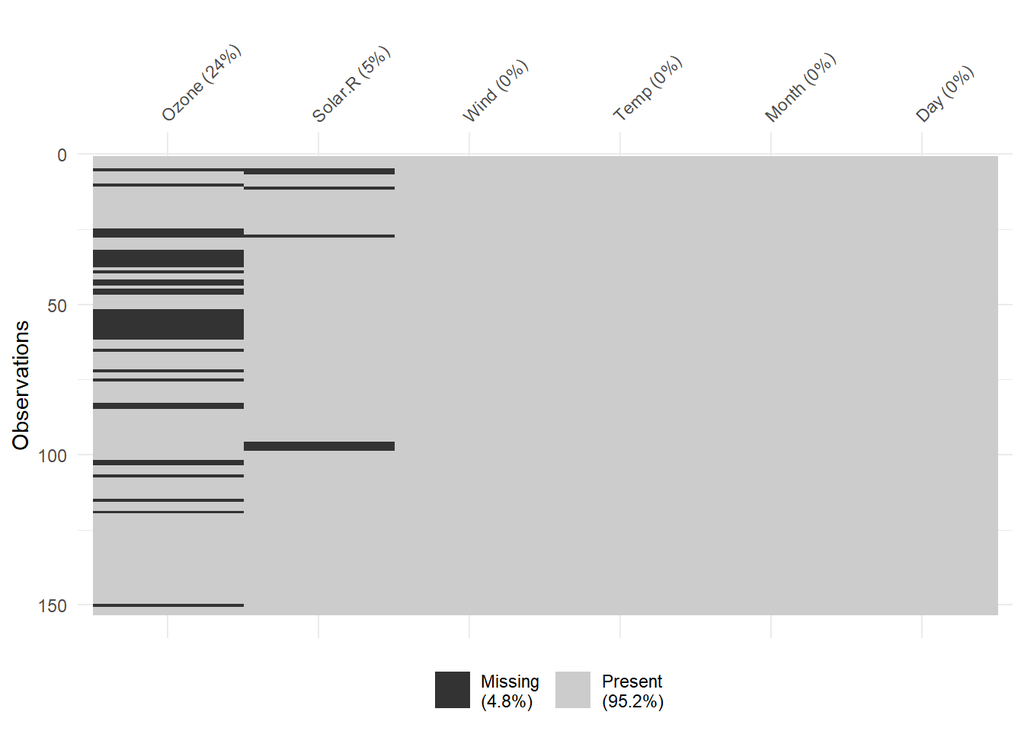

```r
# Visualizar con naniar
vis_miss(airquality)
```

**Ejercicio:**

1. Identificar columnas con valores faltantes.
2. Visualizar el patrón de valores NA.
3. Realizar cálculos estadísticos y visualizaciones eliminando los valores faltantes:
   1. Media, mediana, moda, desviación estándar, mínimo, máximo de las variables físicas (`Ozone`, `Solar.R`, `Wind`, `Temp`).
   2. Boxplots de las variables físicas.
   3. Histogramas de las variables físicas.
   4. Calcular una nueva columna que corresponda al día juliano (1-365) para cada observación.
   5. Gráfico de dispersión entre cada par de variables físicas y variable física - día juliano.
   6. Correlaciones entre cada par de variables físicas y variable física - día juliano.
4. Aplicar imputación de valores perdidos y realizar los mismos cálculos estadísticos y visualizaciones del punto 3.
5. Comparar resultados antes y después de imputar.
6. Para cada variable física:
   1. Calcular la **media** y la **desviación estándar** excluyendo valores faltantes (`NA`).
   2. Definir como **atípico** cualquier valor que esté fuera del rango:
      $$[\mu - 2\sigma, \mu + 2\sigma]$$
      donde:
      - $\mu$ es la media de la variable,
      - $\sigma$ es la desviación estándar de la variable.
   3. Crear una nueva columna para cada variable que indique si el valor es atípico (`TRUE` o `FALSE`).
   4. Mostrar una tabla resumen con:
      - El número total de observaciones.
      - El número de valores atípicos detectados por variable.
      - El porcentaje de valores atípicos respecto al total.
   5. Visualizar los valores atípicos en un **gráfico de dispersión** o **boxplot**, resaltándolos en color diferente.